# Regional Growth and Interregional Connections

Module 2 · ECON 463

Jude Bayham

## Why does a firm choose a particular location?

Decisions depend on economic distance to markets, inputs, and transportation methods as well as access to workers, suppliers, and customers.

## Why build one centralized plant vs. multiple smaller ones?

Economies of scale can make a single large plant cheaper than several smaller ones.

High distribution costs can favor multiple plants closer to customers.

**Modules 4–5.** Workers can commute or move closer to the plant. If housing nearby is scarce, what would you expect to happen to rents? What might sales prices tell us about the value of access to jobs?

## Why do firms cluster?

Agglomeration allow nearby firms to share specialist suppliers, find workers with the skills they need, and learn from one another.

Higher rents and congestion can erode those gains.

**Modules 6–8.** We’ll trace how orders spread through suppliers, allow wages and prices to adjust, and ask who gains from a proposed investment.

## Regional change

Suppose the firm chooses region A.

It may hire workers, buy inputs, and sell goods outside the region.

We want to know what happens to economic activity in region A.

## Five questions about regional growth

1. What defines a region?
2. What initiates a region’s growth?
3. How can exports in one industry impact other industries in the region?
4. When a road links two regions, how do trade and migration change?
5. What would help one region catch up? What could widen the gap?

## Defining a region

What defines a region?

## Which places belong in the region?

A **region** is a set of places grouped by a stated rule. Choose the rule to fit the question.

- **Administrative boundary.** To study a district government’s tax base, use the territory it governs.
- **Shared characteristic.** To study a drought in a rice-growing belt, group places with similar growing conditions.
- **Functional ties.** To study access to jobs, group places connected by regular commuting.

## Whose income is local?

A bakery in Region A pays a baker who lives in Region B.

Together, the two regions form one labor market.

The bakery also pays a flour mill outside both regions.

The wage crosses Region A’s boundary but stays inside the labor market.

The payment for flour goes outside the combined labor market.

## Measuring regional growth

## From one factory to the regional economy

In Module 1 we compared the cost of producing a given quantity at different sites.

Now hold the regional boundary fixed and let both production and population change over time.

A factory can raise regional production and attract new residents.

To interpret the change, we need a measure of production that we can compare across both places and periods.

## Value added and regional output

A producer’s **value added** is the value of its output less the value of the intermediate goods and services.

Let $\mathrm{VA}_i$ denote producer $i$’s value added at common prices. Summing across producers **inside the boundary** gives regional real output.

$$Y = \sum_i \mathrm{VA}_i$$

Holding prices fixed lets us compare quantities across periods.

## When does output per resident rise?

**Output per resident** is $y=Y/N$, total real output divided by population.

Observe the same region twice. In period 0, $y_0=Y_0/N_0$. In period 1, $y_1=Y_1/N_1$.

The ratio $y_1/y_0$ is the **growth factor**. Subtract one to get the **growth rate**, $g_y=y_1/y_0-1$. A factor of 1.10 means 10% growth.

Let $g_Y=Y_1/Y_0-1$ be the growth rate of total output and $g_N=N_1/N_0-1$ the growth rate of population.

$$\frac{y_1}{y_0}
=\frac{Y_1/N_1}{Y_0/N_0}
=\frac{Y_1/Y_0}{N_1/N_0}
=\frac{1+g_Y}{1+g_N}.$$

## Example 1 · River and Harbor

The two fictional regions report production in constant-price currency units (CU).

| Region | Period | Real output (CU) | Residents |
| --- | --- | --- | --- |
| River | 0 | 10,000 | 1,000 |
| River | 1 | 13,200 | 1,200 |
| Harbor | 0 | 15,000 | 1,000 |
| Harbor | 1 | 16,800 | 1,050 |

**River’s output per resident** rose from 10,000/1,000 = 10 to 13,200/1,200 = 11 CU.

## Labor productivity and the mix of jobs

What initiates a region’s growth?

## From residents to workers

Our first comparison counted everyone who lives in the region.

Now distinguish the people who produce output from the population as a whole.

Let $L$ be the number of workers. **Labor productivity** is output per worker, $Y/L$.

**Workers per resident**, $L/N$, includes children and retirees in its denominator.

Multiplying the two ratios recovers output per resident:

$$\frac{Y}{N}=\frac{Y}{L}\frac{L}{N}.$$

## How the mix of jobs affects productivity

So far we have treated workers as one group. Now divide them between two sectors.

**Labor reallocation** changes how workers are distributed across sectors.

Let $p_A$ and $p_B$ be productivities (output per worker) in each sector and $s$ the share of workers in B.

Regional productivity is their weighted average:

$$Y/L=(1-s)p_A+s p_B.$$

With sector productivities fixed, shifting a share $\Delta s$ into B changes the regional average by $(p_B-p_A)\Delta s$.

## Example 1 · Moving 100 workers

Suppose 100 workers move from agriculture into other activities within the region, River.

| Sector | Workers before | Workers after | Output per worker (CU) |
| --- | --- | --- | --- |
| Agriculture | 300 | 200 | 10 |
| Other activities | 200 | 300 | 35 |

## The economic base

## What could start regional growth?

Growth can start with a change in what buyers want or in what producers can supply.

**Demand.** When buyers place more orders, firms with spare capacity can expand production and hire workers.

**Supply.** New equipment, skills, or cheaper inputs let firms produce more with the same resources. Output can also rise when workers move into more productive activities.

How do these explanations align with macroeconomic growth theory?

## The region and its economic base

Choose a **region** and draw its boundary.

An **export** is a good or service sold to a customer from outside that boundary.

Under the export-sales definition, **basic activity** serves outside customers. These activities together form the **economic base**.

**Nonbasic activity** serves customers within the region.

An industry can serve both groups. Its basic share depends on where its customers live.

## How outside demand enters the model

Split a firm’s sales $S$ by where its customers live.

Let $S_E$ be export sales and $S_L$ sales to local customers.

$$S=S_E+S_L,\qquad \text{basic share of sales}=S_E/S \quad (S>0).$$

The export-base model takes outside orders as given.

When those orders increase, exporters may hire workers or buy local inputs.

Those earnings can generate demand for local businesses.

## Services can be part of the base

An **export** crosses the regional boundary, not necessarily a national border.

Alternatively, the customer can come to the product: visitors buy local lodging and meals.

## Classify sales, not just firms or the whole industry

A River restaurant sells **100 CU** of meals:

- **80 CU** to visitors from outside River.
- **20 CU** to River residents.

Its sales are **80% basic and 20% nonbasic** under the export-sales definition. One establishment can do both.

## Local services support the base

A River repair shop serves a local processor that exports rice.

The repair sale is local, but its demand is **indirectly tied to exports** (via the rice processor).

Some base studies include these indirect export activities in the base. Be clear about the classification rule you use.

**Local services and imported inputs can make export production possible.**

## The regional income multiplier

How can exports in one industry impact other industries in the region?

## How export demand reaches other industries

An exporter that produces more may **buy more inputs**.

That creates demand in supplier industries, such as equipment repair or transport.

It may also **pay more wages**. When households spend their additional earnings, other industries, such as food retail, gain customers.

## From export sales to local income

An export order generates an initial gain in residents’ income, $\Delta X$. What happens when residents spend some of that income?

For each extra currency units (CU) residents earn, let $s$ be the share they spend at local businesses.

Of each CU those businesses receive, let $v$ be the share that becomes income for local residents.

The **feedback coefficient** is $b=s\times v$. It tells us how much of one round’s income returns as residents’ income in the next round.

## Income multiplier

Start with the direct gain $\Delta X$.

As the money circulates through the local economy, each round generates a fraction $b$ of its income in the next round, with $0\leq b<1$.

$$\Delta I=\underbrace{\Delta X}_{\text{first round}}+
\underbrace{b\Delta X+b^2\Delta X+\cdots}_{\text{all later rounds}}.$$

Multiply the whole series by $b$ and it starts one round later. That is why **later rounds alone** sum to $b\Delta I$.

$$\Delta I=\Delta X+b\Delta I
\quad\Longrightarrow\quad
m=\frac{\Delta I}{\Delta X}=\frac{1}{1-b}.$$

## Regional economic impact

Harbor places an extra order with River’s rice processor.

The processor might hire River’s repair shop.

Workers who earn extra pay might spend some at the local grocer.

If the shop buys parts from Harbor, that spending **leaves** River.

## Example 2: outside demand adds local income

Suppose the order raises River residents’ income by 100 CU after the processor pays for supplies from outside River.

Households spend 80% of each extra CU at River businesses.

Of each CU those businesses receive, 75% becomes income for River residents.

## Example 2: solve the feedback equation

Use the 100-CU direct gain and the feedback coefficient of 0.60.

How much income comes from the rounds after the direct gain?

$$\Delta I=\frac{\Delta X}{1-b}=\frac{100}{1-0.60}=250.$$

Of the **250 CU** total, **100 CU** comes from the order itself. All later rounds together add **150 CU**.

The multiplier is **2.5**.

## Example 2: reduce local feedback

Suppose $b$ was **0.40** instead of 0.60.

The total effect of the same 100-CU direct addition falls to

$$\Delta I=100/(1-0.40)=166.7\text{ CU}.$$

The difference comes from subsequent rounds, not the initial shock.

## Example 2: follow the accounting rounds

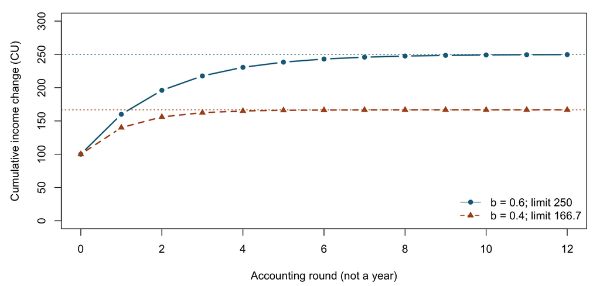

## A demand multiplier depends on assumptions

Hold prices and feedback relationships fixed. Businesses use the same technologies and inputs

Assume available workers and capacity, without displacement of other production.<sup>1</sup>

**A one-time level increase is not sustained productivity growth.**

[^1]: See the reader’s “Demand, supply, and local feedback” and Hoover–Giarratani §11.2 and the opening of §11.3.1.

# Break 10 min

## Market access and interregional trade

When a road links two regions, how do trade and migration change?

## From a regional boundary to a trade route

In the multiplier model, purchases from Harbor left River’s income calculation.

From Harbor’s perspective, those purchases are sales.

Now keep track of buyers and sellers at both ends of the route.

**Market access** describes the buyers a producer can reach at a given cost.

The **delivered price** includes the seller’s price and the cost of getting the good to the buyer.

## When does a buyer switch suppliers?

A Harbor buyer can pay $p_H$ locally or buy the same good from River at price $p_R$ plus freight $t$ per unit.

Hold seller prices and quality fixed.

River can undercut the local supplier if $p_R+t<p_H$

Rearranging gives the freight threshold $t^*=p_H-p_R$. When $t$ falls below that threshold, River becomes cheaper for the Harbor buyer.

## Example 3: improve a transport corridor

**River:** agricultural production. **Harbor:** manufacturing and services.

Compare the same period **with and without** lower transport costs.

Suppose a unit of grain costs 8 CU in River and 11 CU in Harbor.

A road improvement reduces freight cost from 4 to 2 CU per unit.

River’s delivered price falls from 12 to 10 CU.

It gains access to this buyer once freight falls below 3 CU.

## Access changes costs and revenue

River farmers may reach more buyers.

Harbor firms may supply River more cheaply.

Both may obtain better inputs, but local competitors can lose sales.

Cheaper transport does not guarantee that every region gains jobs.

## Migration and the cost of moving

When a road links two regions, how do trade and migration change?

## From shipping goods to moving workers

A new road can put a job within commuting distance.

A worker may keep their home and travel to work, or **migrate** by moving closer to the job.

Compare the costs of living and traveling under each choice.

Let $w_j$ be annual wages in region $j$ and $c_j$ annual housing and commuting costs.

The **remaining budget** is $w_j-c_j$.

Moving also costs $F$ once. The worker expects to stay for $T$ years.

## The break-even condition for moving

Let $d=(w_H-c_H)-(w_R-c_R)$ be the annual budget gain from moving to Harbor.

With constant annual budgets and no discounting,

$$\text{Gain over }T\text{ years}=T d-F.$$

The move raises the worker’s remaining budget if $Td>F$.

When $d>0$, the break-even horizon is $T^*=F/d$.

## Example 3: would a worker move?

Illustrative annual budgets, in CU:

|  | River | Harbor |
| --- | --- | --- |
| Wage | 100 | 140 |
| Housing and commuting | 40 | 70 |
| Remaining budget | 60 | 70 |

One-time moving cost: **15 CU**.

## Example 3: the horizon changes the comparison

The annual budget gain is $70-60=10$ CU.

It takes $15/10=1.5$ years to recover the moving cost.

First-year gain: $(140-70)-15-(100-40)=\mathbf{-5}$ CU.

Three-year gain: $3(70-60)-15=\mathbf{15}$ CU.

## Origins and destinations both adjust

**Harbor:** more workers and customers, housing demand, possible congestion.

**River:** fewer workers and customers, possible remittances from workers that moved.

Wages depend on both labor supply and firms’ demand for workers.

## Rural–urban links change who benefits

Consider **farmers, retailers, renters, and property owners** separately.

Food and input purchases, commuting, remittances, and services connect their outcomes.<sup>1</sup>

[^2]: See the reader’s “Market access and trade” and “Migration, capital, and rural–urban connections”, along with Hoover–Giarratani §11.5.

## Regional convergence

What would help one region catch up? What could widen the gap?

## From flows between regions to gaps over time

Cheaper trade and migration connect the two regions.

To see whether their economies are becoming more alike, we need to choose an outcome and a comparison.

**Convergence** means the regions become more similar by a stated measure.

**Divergence** means they grow farther apart. We’ll compare real output per resident, using River as the initially lower-output region.

## Two ways to measure catch-up

Write $y_R$ and $y_H$ for output per resident in River and Harbor.

Suppose $0<y_R<y_H$ throughout the comparison.

| Criterion | Measure | When does River catch up? |
| --- | --- | --- |
| Absolute gap | $G=y_H-y_R$ | $G$ falls when River gains more CU per resident. |
| Relative position | $q=y_R/y_H$ | $q$ rises toward 1 when River grows faster in percentage terms. |

## Why catch-up is not automatic

**Catch-up**: If firms in the lower-output region adopt a more productive technique, output per worker can grow faster there.

**A widening gap**: If new firms in the leading region attract specialist suppliers, existing firms there can also become more productive. That advantage can draw in still more firms.

Rising land costs and congestion can restrict a region from growing much faster than others.<sup>1</sup>

[^3]: See the reader’s “Convergence and divergence” and Hoover–Giarratani §11.6.

## Evidence must match the mechanism

| Explanation | Useful observations |
| --- | --- |
| Better access | Freight costs, reliability, shipment destinations |
| Productivity | Output, inputs, worker and industry composition |
| Migration | Job offers, housing costs, flows of people |

## Five questions revisited

1. **Region.** The question determines the boundary. An administrative district may be suitable for a tax question while a commuting area might be more appropriate for a jobs question.
2. **Growth.** Demand can draw idle resources into production (underutilized capacity). Investment, new skills, and changes in the mix of jobs can raise productive capacity or output per worker.
3. **Exports.** Exporters buy inputs and pay workers. Local suppliers and the businesses where households spend those earnings can gain sales.
4. **Roads.** Lower freight costs can change who trades. Cheaper travel can make commuting feasible. Moving depends on jobs, living costs, and the cost of relocating.
5. **Catch-up.** Technology can spread to the lagging region, or suppliers and workers can concentrate in the leader. Track the gap in a specified outcome.

## Synthesis and the Module 3 bridge

For the corridor, write:

1. A with/without comparison.
2. One transmission mechanism and one constraint.
3. One observation that would help assess the explanation.

**Next:** choose boundaries and comparable data, then measure regional structure.

## Readings

**Assigned reading.** Read “How Regions Develop” from the start of Chapter 11 through §11.6, “Interregional Convergence” (Hoover and Giarratani 2020). Stop at the §11.7 heading.

Printed pp. 217–239 (PDF pp. 218–240), **23 pages**.

**Within the assignment.** §11.3.1 introduces the economic base. In §11.3.2, follow how a new order changes purchases across industries. Module 6 develops the calculations.

**Supporting reading.** §10.3, pp. 197–208, on migration.

**Optional:** §11.7, pp. 239–242, on cities and regional development.

Full explanations, worked answers, and printed/PDF page conversions: **companion reader**.

Hoover, Edgar M., and Frank Giarratani. 2020. *An Introduction to Regional Economics*. 4th ed. Regional Research Institute, West Virginia University.

## Optional practice · Follow a program order

A festival in Region B orders programs from a printer in Region A. The printer hires a bindery in A and buys paper from outside both regions. A printer’s employee lives in B and spends the extra pay at a café there.

## Optional practice · Who earns the order revenue?

The printer can fill either order. The bindery in A is at capacity with the smaller order. It spends 40% of its fee on imported materials and pays the rest to A’s residents.

| How the printer spends the order revenue (CU) | 400 CU order | 600 CU order |
| --- | --- | --- |
| Wages to residents of A | 120 | 180 |
| Wages to commuters from B | 80 | 120 |
| Fee to the bindery in A | 100 | 100 |
| Fee to a bindery outside A | 0 | 50 |
| Paper from outside A | 100 | 150 |

## Optional practice · Which order generates more local income?

The 400 CU order initially puts 180 CU in residents’ hands. The 600 CU order puts 240 CU in their hands.

In each round, households spend 80% of their extra income at businesses in A. Half of those sales becomes income for A’s residents. Assume prices and these shares stay fixed.